# Statistical analysis of USA transportation infrastructure

Magdalena Marecik

## Introduction

Transport infrastructure has played a crucial role in the development of the American economy for years. It determines in which parts of the country economic growth will occur and which regions will incur losses. Currently, the state of the transport infrastructure in the USA is assessed as average. In March 2021, the American Society of Civil Engineers, in its Infrastructure Report Card, awarded the American transportation system a grade of C-minus [(link to the report)](https://infrastructurereportcard.org/). Overall, there has been a slight improvement compared to 2017 when transportation in the USA was rated a D-plus in the same report. At the same time, the report’s authors emphasize that many areas such as public transport, airports, and the condition of roads, highways, and bridges show significant deterioration and “considerable risk of failure.” Furthermore, the authors estimate that almost half of the US population does not have access to public transportation. According to other studies, delays caused by traffic congestion — often due to inadequate infrastructure — result in economic losses exceeding $120 billion annually.

Among American policymakers, debates are still ongoing about transportation infrastructure projects that should be adopted to improve its condition and how to finance them.

On the other hand, in some parts of America, the transportation infrastructure is maintained at a high level. In the ranking published by U.S. News - 2021 Best States rankings [(link to the ranking)](https://www.usnews.com/news/best-states/rankings/infrastructure/transportation), we can see which states have achieved the highest scores, considering the condition of roads and bridges within their territories, as well as the degree of congestion and the average time residents spend commuting to work. This ranking served as inspiration for conducting a statistical analysis of the transportation condition in individual states of America. The study will include creating a ranking of states in terms of transportation infrastructure and classifying them into groups possesing characteristic features. The aim of the analysis is an attempt to find answers to the following questions:

- Which states have the best and worst transportation infrastructure, considering all the factors examined?
- Which states are characterized by similar financial infrastructure conditions, and which ones differ significantly?
- How many groups with significantly different transportation conditions can we distinguish among the 50 states of America?

## Explanatory Data Analysis

The dataset used in the project was created based on data collected from American websites. These websites provide national statistics by gathering information from various sources, such as the United States Department of Transportation. The data includes selected metrics related to the condition of transportation infrastructure in individual states of America:

- Average daily commute time for individuals aged 16 and above, 2014-2018 (minutes) [(link)](https://www.indexmundi.com/facts/united-states/quick-facts/all-states/average-commute-time#map)
- Number of hours spent annually by the average driver in traffic congestion, 2017 (hours) [(link)](https://reason.org/policy-study/24th-annual-highway-report/urbanized-area-congestion/)
- Number of deaths in motor vehicle crashes per 100 million vehicle miles traveled, 2019 [(link)](https://www.iihs.org/topics/fatality-statistics/detail/state-by-state)
- Percentage of roads in good condition, 2019 (%) [(link)](https://www.bts.gov/road-condition)
- Percentage of bridges in poor condition, 2019 (%) [(link)](https://www.bts.gov/bridge-condition)

In order to minimize the risk of making errors and be able to interpret the obtained results better, before the right research, it is advised to perform an explanatory data analysis.

### Descriptive statistics

|  | vars | n | mean | sd | median | trimmed | mad | min | max | range | skew | kurtosis | se |
| --- | --- | --- | --- | --- | --- | --- | --- | --- | --- | --- | --- | --- | --- |
| travel_time_to_work | 1 | 51 | 24.5274510 | 3.9183200 | 24.6000000 | 24.5000000 | 3.8547600 | 17.0000000 | 33.3000000 | 16.3000000 | 0.0401381 | -0.3746127 | 0.5486745 |
| hours_in_congestion | 2 | 51 | 22.8149020 | 15.4279254 | 18.2800000 | 20.2978049 | 12.0238860 | 7.2500000 | 70.1500000 | 62.9000000 | 1.3085025 | 1.0100683 | 2.1603417 |
| fatalities | 3 | 51 | 1.1374510 | 0.2777398 | 1.1000000 | 1.1363415 | 0.2965200 | 0.5400000 | 1.8300000 | 1.2900000 | 0.1224082 | -0.5874852 | 0.0388913 |
| roads_in_acceptable_conditions | 4 | 51 | 0.8071448 | 0.1062345 | 0.8249003 | 0.8176815 | 0.1067031 | 0.4968075 | 0.9635051 | 0.4666976 | -0.8601455 | 0.5568296 | 0.0148758 |
| bridges_in_poor_conditions | 5 | 51 | 0.0619984 | 0.0404710 | 0.0513719 | 0.0580000 | 0.0385679 | 0.0073008 | 0.2391387 | 0.2318379 | 1.6896448 | 5.0556601 | 0.0056671 |

#### Average daily commute time

When calculating the mean of the average commuting time for residents of individual states, it turns out that Americans spend on the average less than 25 minutes per day commuting to work, with a standard deviation of about 4 minutes. The negative kurtosis indicates that the number of extreme values is smaller than in the case of a normal distribution, as observed in the histogram below. One might suspect that there are no outliers among the values of this variable. It turns out that the residents of New York spend the most time commuting to work, specifically 33.3 minutes on average, while the citizens of South Dakota spend the least average amount of time - about 17 minutes.

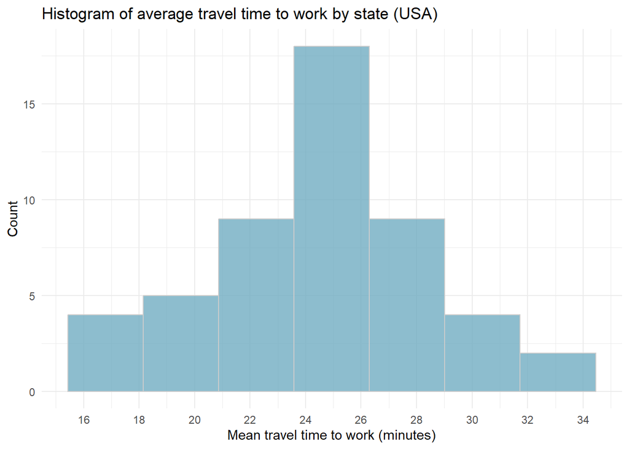

#### Number of hours spent annually in traffic congestion

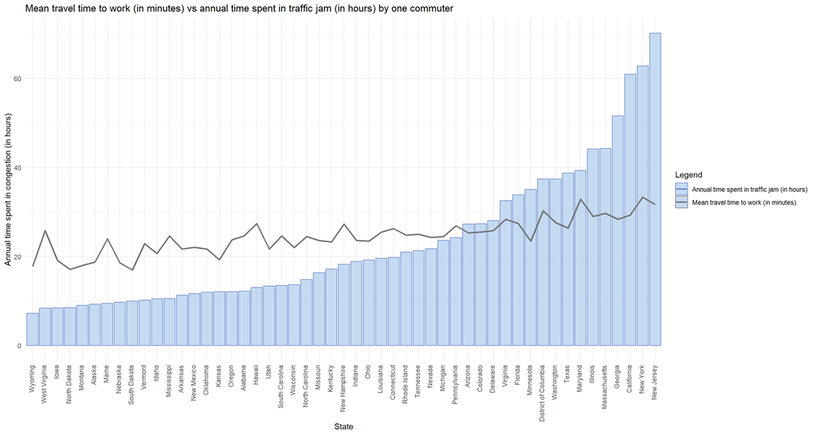

```
## # A tibble: 1 × 6
##   state      travel_time_to_work hours_in_congestion fatalities
##   <chr>                    <dbl>               <dbl>      <dbl>
## 1 New Jersey                31.7                70.2       0.73
## # ℹ 2 more variables: roads_in_acceptable_conditions <dbl>,
## #   bridges_in_poor_conditions <dbl>
```

#### Number of deaths in motor vehicle crashes

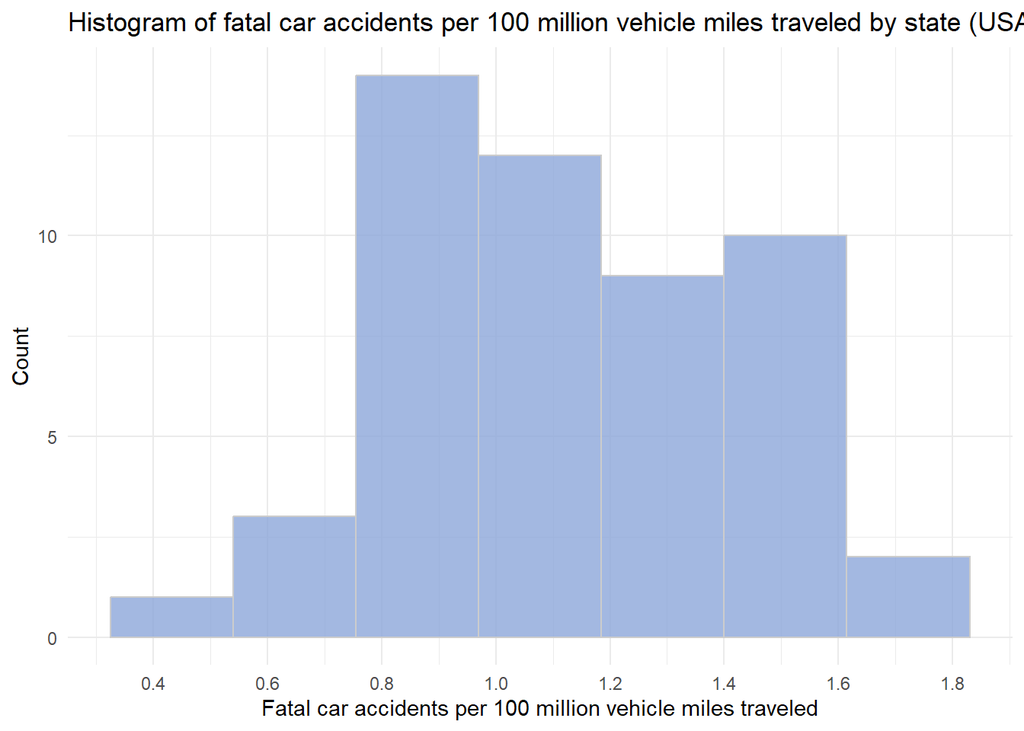

#### Roads and bridges condition

In America, approximately 81% of roads are in good condition, with a standard deviation of 11 percentage points. The best road conditions are found in Idaho, a state in the northwest of the United States, where over 96% of roads are in good condition. On the other hand, the worst road conditions among all states are in Rhode Island, the northeastern part of the USA.

On average, 6% of bridges in the United States are in poor condition, with an average deviation of 4 percentage points. Similar to roads, the highest percentage of bridges in poor condition is found in Rhode Island, reaching 24%. Utah, a state in the Midwest of the United States, has the best bridge conditions. The high kurtosis value of the distribution of this variable indicates a leptokurtic distribution and the potential occurrence of extreme observations.

#### Outliers

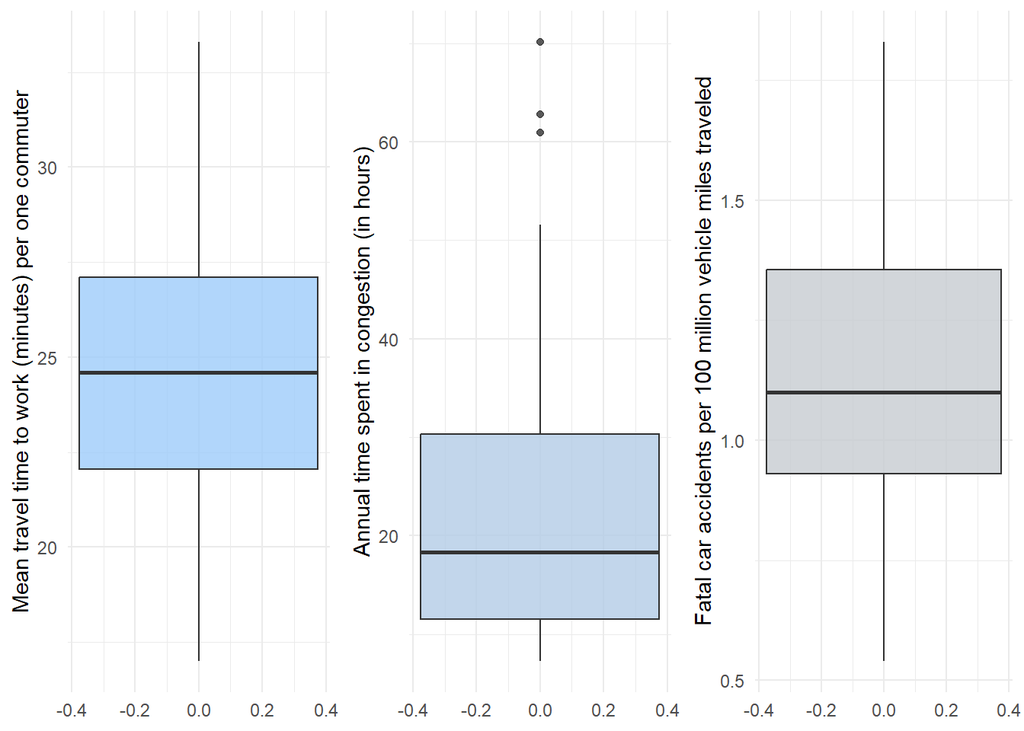

In the next stage, we will analyze our data in terms of outliers. The analysis of box plots for the first three variables confirms our earlier assumptions. Among the average commute time and the fatality rate in road accidents, there are no outlier values. However, extreme values are present in the case of the average number of hours spent in traffic jams. It can be inferred that some states are characterized by a significantly longer time that residents have to spend in traffic jams than others. At the forefront are New Jersey (70.15 hours), New York (62.76 hours), and California (60.91 hours).

```
## # A tibble: 3 × 6
##   state      travel_time_to_work hours_in_congestion fatalities
##   <chr>                    <dbl>               <dbl>      <dbl>
## 1 California                29.3                60.9       1.02
## 2 New Jersey                31.7                70.2       0.73
## 3 New York                  33.3                62.8       0.76
## # ℹ 2 more variables: roads_in_acceptable_conditions <dbl>,
## #   bridges_in_poor_conditions <dbl>
```

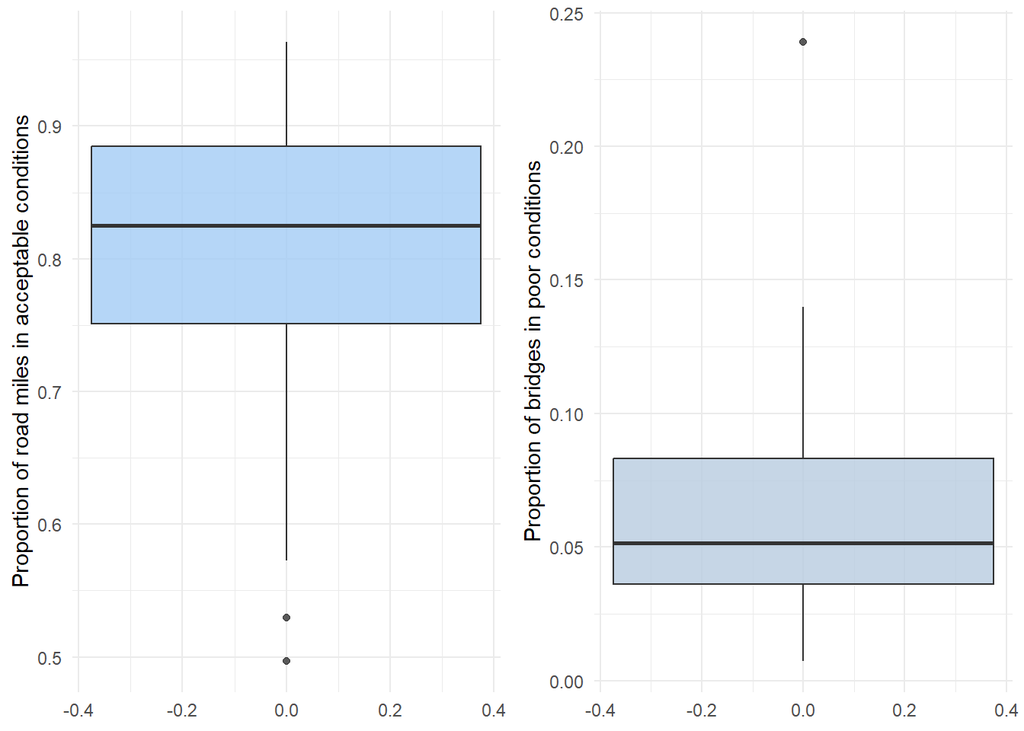

Among the variables related to the condition of roads and bridges in the USA, there are also outlier observations. It can be noticed that some states are characterized by a significantly worse condition of roads and bridges than others. In terms of both factors, Rhode Island stands out, as well as New Jersey, where only 53% of roads are in an acceptable condition.

In the study, identified outlier observations will not be removed, as they contribute to greater variability in the data and provide a starting point for dividing objects into groups with different characteristics.

#### Coefficient of variation

```
## [1] "travel_time_to_work"
## [1] 0.1597524
## [1] "hours_in_congestion"
## [1] 0.6762214
## [1] "fatalities"
## [1] 0.2441773
## [1] "roads_in_acceptable_conditions"
## [1] 0.1316176
## [1] "bridges_in_poor_conditions"
## [1] 0.6527748
```

Since we want to divide our objects into groups with different characteristics, a significant factor in selecting variables for the cluster analysis model is their sufficient variability. In the case of the discussed variables, all of them have a coefficient of variation greater than 10%, so there is no obstacle to using them in the study.

#### Correlation

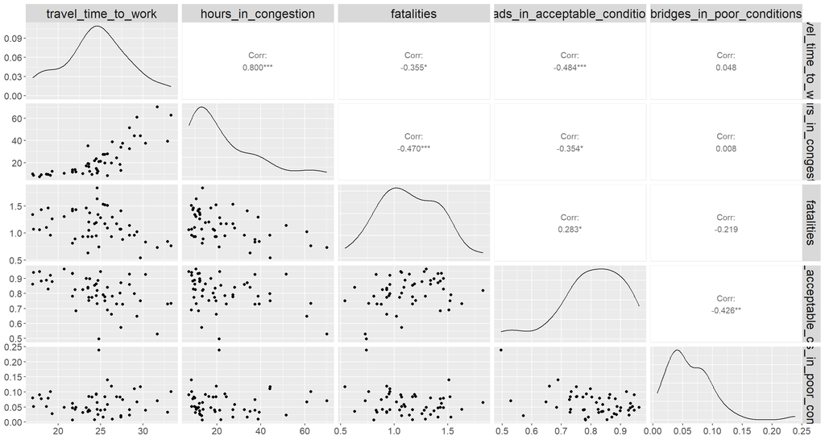

When variables used for cluster analysis are too strongly correlated, they may carry more weight than other variables, representing the same phenomenon. This can badly influence the final result because the solution may lean towards the concept to which, due to too much correlation between variables, greater weight has been assigned. Therefore, we do not want our variables to be collinear. On the chart above, it can be observed that the variables used in the study are not strongly correlated with each other, as in each case, the correlation coefficient is less than 90%.

## Linear ordering

In this part of the study, the entities present in the dataset, which are individual states of America, will be ranked based on the values of the presented variables - from “best” to “worst.” To rank the entities, it is necessary to establish certain criteria, allowing, for example, to classify an entity as better. For this purpose, all variables in the dataset have been transfered to stimulants.

In the next step, we standardize the data by subtracting the mean from each observed value and dividing by the standard deviation so that variables (given in different units) are comparable to each other.

#### Hellwig method of Linear Ordering

The Hellwig’s method of linear ordering is an example of a reference method. This means that the ranking will be created based on the distances of objects from a designated pattern, i.e., the best possible object. The determined reference in the study takes the following values of variables (after standardization):

```
## [1] 1.921091 1.008878 2.151118 1.471841 1.351526
```

The next step is calculation of distance from each entity to the ideal object:

$$d_i = \sqrt{\sum{(x_{ij}-d_j^+)^2}}$$

and finding the “possibly largest” distance:

$$d_0 = \bar{d_i} + 2 * s(d_i)$$

Then final step is to calculate the values of the measure for each object according to the formula below. Objects sorted according to the measure below (from largest to smallest) will create the final ranking.

$$s_i = 1 - \frac{d_{i0}}{d_0}$$

The obtained results can be interpreted by grouping objects according to the average ranking value. States are divided into 4 groups - with the best, above-average, below-average, and the lowest number of points obtained in the ranking (ranking variable). The final result can be seen in the table below:

| state | hellwig_score | hellwig_rank | hellwig_group |
| --- | --- | --- | --- |
| North Dakota | 0.6597185 | 1 | 1 |
| Utah | 0.6398269 | 2 | 1 |
| Wisconsin | 0.6281267 | 3 | 1 |
| Nebraska | 0.6241097 | 4 | 1 |
| Vermont | 0.6130346 | 5 | 1 |
| Ohio | 0.5861569 | 6 | 1 |
| Wyoming | 0.5697757 | 7 | 1 |
| Minnesota | 0.5667105 | 8 | 1 |
| Kansas | 0.5627446 | 9 | 1 |
| Iowa | 0.5617005 | 10 | 1 |

#### TOPSIS method of Linear Ordering

The TOPSIS method is analogous to the Hellwig method, with the difference that objects are compared not only to the “ideal object” but also to the “anti-ideal”.

After converting variables into stimulants and determining the normalized matrix according to the formula below:

$$z_{ij} = \frac{x_{ij}}{\sqrt{\sum_{i=1}^{m}{x_{ij}^2}}}$$

we can find an ideal and anti-ideal objects:

```
## [1] -0.09586171 -0.03697462 -0.06461600  0.16575267 -0.01384854
```

```
## [1] -0.18777617 -0.35776128 -0.21897645  0.08546625 -0.45361046
```

As the next step, we calculate distances from the best and the worst object.

Based on this, we determine the ranking coefficient indicating how similar a given object is to the ideal solution. Similar to before, states have been assigned to 4 groups based on the obtained ranking points.

```
## # A tibble: 10 × 4
##    state        topsis_score topsis_rank topsis_group
##    <chr>               <dbl>       <int>        <dbl>
##  1 Utah                0.900           1            1
##  2 Vermont             0.867           2            1
##  3 Wisconsin           0.842           3            1
##  4 Kansas              0.837           4            1
##  5 Ohio                0.827           5            1
##  6 North Dakota        0.826           6            1
##  7 Nevada              0.818           7            2
##  8 Alabama             0.818           8            2
##  9 Nebraska            0.818           9            2
## 10 Hawaii              0.815          10            2
```

The results of creating a ranking for 50 states of America in terms of transportation infrastructure using the Hellwig and TOPSIS methods are as follows:

```
##           state hellwig_score hellwig_rank hellwig_group topsis_score
## 35 North Dakota     0.6597185            1             1    0.8256146
## 45         Utah     0.6398269            2             1    0.8998092
## 50    Wisconsin     0.6281267            3             1    0.8420426
## 28     Nebraska     0.6241097            4             1    0.8175605
## 46      Vermont     0.6130346            5             1    0.8674526
## 36         Ohio     0.5861569            6             1    0.8266921
## 51      Wyoming     0.5697757            7             1    0.7269887
## 24    Minnesota     0.5667105            8             1    0.7437215
## 17       Kansas     0.5627446            9             1    0.8369543
## 16         Iowa     0.5617005           10             1    0.7018755
##    topsis_rank topsis_group
## 35           6            1
## 45           1            1
## 50           3            1
## 28           9            2
## 46           2            1
## 36           5            1
## 51          24            2
## 24          20            2
## 17           4            1
## 16          33            3
```

```
## [1] 2
```

```
## [1] 35
```

Only 2 out of 51 states found themselves in the same positions when ranked by both methods. However, it can be observed that “better” objects in both cases are consistently ranked high, while states with worse transportation infrastructure always rank low. Intermediate objects also often assume similar positions in both rankings. This confirms that 35 states fell into the same group in both methods.

The Pearson linear correlation coefficient between the values of ranking variables (Hellwig score and TOPSIS score) is 0.85. The Spearman rank correlation coefficient between positions in the ranking (Hellwig rank and TOPSIS rank) is 0.8.

Depending on the linear ordering method used, we obtain a different ranking of states in terms of transportation infrastructure. Differences arise from algorithmic variations. Although both methods are benchmark and use Euclidean distance, in the TOPSIS method, objects are additionally compared to the anti-ideal. The normalization method and the way of determining ranking variables are also different.

## Cluster analysis

Cluster analysis is an unsupervised classification method, meaning that with only certain X variables, we aim to discover dependencies between them without utilizing a Y variable. The goal of the method is to divide objects in such a way that elements within the same group are as similar as possible, while the constructed groups differ as much as possible from each other. Classification algorithms are divided into two main types: divisive clustering and hierarchical clustering.

The starting point for cluster analysis is the standardization of variables because we want each variable to have a similar, unit-independent impact on the analysis result. Standardization ensures the comparability of variables, as they are expressed on the same scale.

In classification methods, similarity or distance measures between objects are used in the formation of clusters. Our clustering algorithms will be based on distance functions. The matrix below shows the distance (Euclidean) between individual states in the context of transportation infrastructure. In the plot, the red color indicates significant differences between individual states, while the blue color means that two objects are similar.

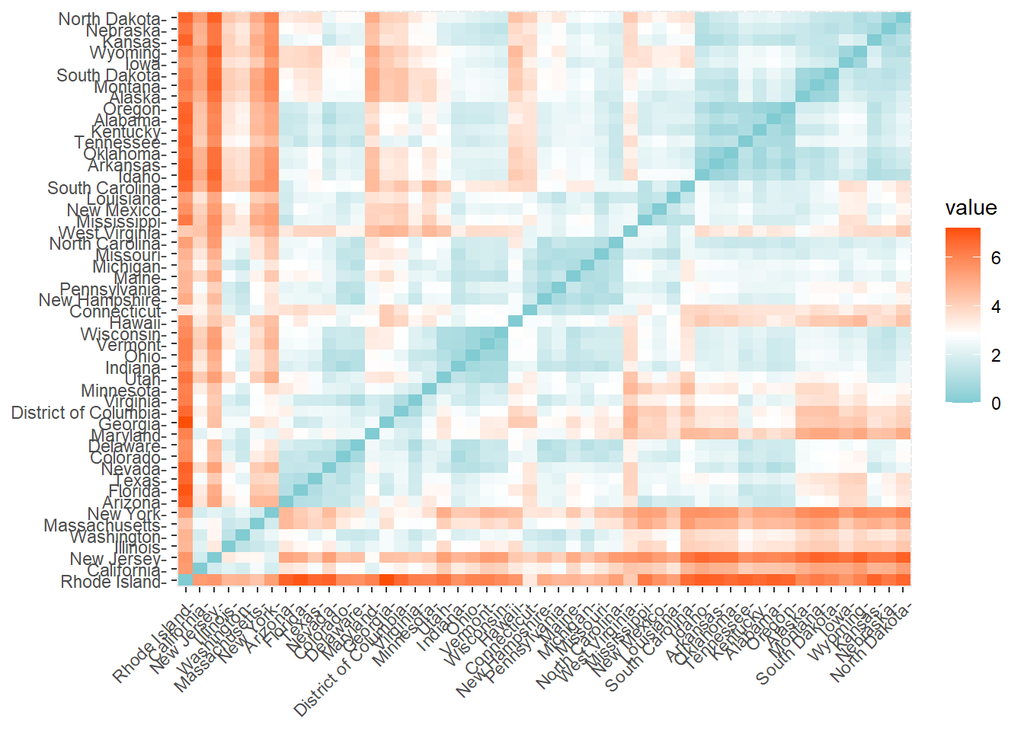

### Divisive clustering

In divisive clustering, objects are divided into k disjoint clusters, where k is predefined. However, there are methods that assist in selecting the appropriate number of clusters. The most popular divisive clustering algorithm is the k-means method.

#### K-means clustering

In the k-means method, each cluster is represented by a centroid, which is a vector of mean values along the coordinates. Because objects in the initial clusters are randomly selected, the algorithm produces different final results depending on the starting point (it seeks a local minimum, not a global one). This issue can be partially addressed by conducting the procedure multiple times and then selecting the solution in which objects within groups differ the least. The algorithm is sensitive to outliers, so we expect some issues with Rhode Island, which stood out significantly from other states in terms of road and bridge conditions and had one of the lowest fatality rates in accidents.

As a result of the initial k-means clustering, two groups were obtained with descriptive statistics shown in the tables below. The first group, consisting of 16 states, is characterized by a longer average commute time and time spent in traffic compared to the second group (35 objects). At the same time, it has a much lower fatality rate in traffic accidents than the second group.

```
##
##  Descriptive statistics by group
## group: 1
##                                vars  n  mean    sd median trimmed   mad   min
## travel_time_to_work               1 16 28.38  2.85  28.40   28.37  2.52 23.50
## hours_in_congestion               2 16 38.57 16.55  37.40   38.14 19.96 13.04
## fatalities                        3 16  0.88  0.18   0.90    0.89  0.19  0.54
## roads_in_acceptable_conditions    4 16  0.73  0.13   0.73    0.74  0.12  0.50
## bridges_in_poor_conditions        5 16  0.08  0.05   0.07    0.07  0.05  0.02
##                                  max range  skew kurtosis   se
## travel_time_to_work            33.30  9.80  0.07    -0.99 0.71
## hours_in_congestion            70.15 57.11  0.33    -1.04 4.14
## fatalities                      1.17  0.63 -0.18    -0.92 0.04
## roads_in_acceptable_conditions  0.93  0.43 -0.23    -0.95 0.03
## bridges_in_poor_conditions      0.24  0.22  1.39     1.98 0.01
## ------------------------------------------------------------
## group: 2
##                                vars  n  mean   sd median trimmed  mad   min
## travel_time_to_work               1 35 22.77 2.97  23.60   22.89 2.82 17.00
## hours_in_congestion               2 35 15.61 7.68  12.25   14.54 4.74  7.25
## fatalities                        3 35  1.25 0.24   1.28    1.25 0.27  0.81
## roads_in_acceptable_conditions    4 35  0.84 0.07   0.84    0.84 0.09  0.68
## bridges_in_poor_conditions        5 35  0.05 0.03   0.05    0.05 0.03  0.01
##                                  max range  skew kurtosis   se
## travel_time_to_work            27.40 10.40 -0.49    -0.94 0.50
## hours_in_congestion            38.73 31.48  1.30     0.99 1.30
## fatalities                      1.83  1.02  0.11    -0.64 0.04
## roads_in_acceptable_conditions  0.96  0.28 -0.25    -0.85 0.01
## bridges_in_poor_conditions      0.14  0.13  0.54     0.02 0.01
```

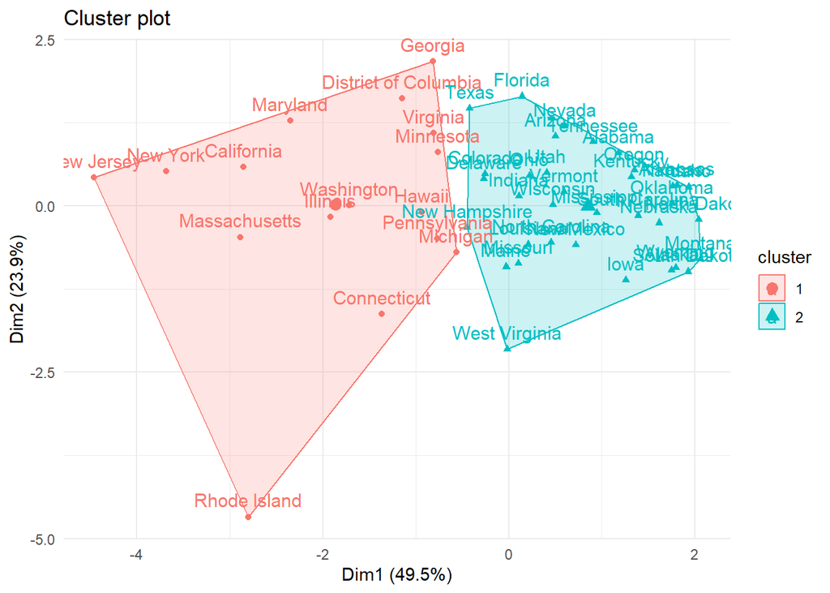

Below are the results of k-means clustering for 2 groups after removing Rhode Island from the dataset. We can see that a few objects have been assigned to a different group than before, but overall, the division has not changed significantly. Also, descriptive statistics in individual groups have changed only slightly. One of the groups (left) still has a longer average commute time, time spent in traffic, and a lower fatality rate in traffic accidents.

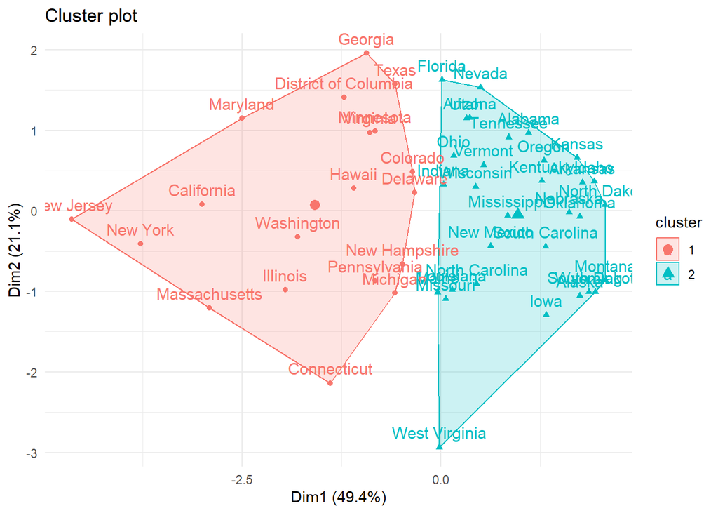

```
##
##  Descriptive statistics by group
## group: 1
##                                vars  n  mean    sd median trimmed   mad   min
## travel_time_to_work               1 19 28.12  2.67  27.60   28.08  2.52 23.50
## hours_in_congestion               2 19 37.29 15.66  37.40   36.79 14.91 13.04
## fatalities                        3 19  0.95  0.20   0.96    0.95  0.19  0.54
## roads_in_acceptable_conditions    4 19  0.76  0.11   0.78    0.76  0.07  0.53
## bridges_in_poor_conditions        5 19  0.06  0.03   0.07    0.06  0.04  0.01
##                                  max range  skew kurtosis   se
## travel_time_to_work            33.30  9.80  0.34    -0.75 0.61
## hours_in_congestion            70.15 57.11  0.49    -0.73 3.59
## fatalities                      1.29  0.75 -0.33    -0.74 0.04
## roads_in_acceptable_conditions  0.93  0.40 -0.42    -0.37 0.02
## bridges_in_poor_conditions      0.12  0.11  0.13    -1.39 0.01
## ------------------------------------------------------------
## group: 2
##                                vars  n  mean   sd median trimmed  mad   min
## travel_time_to_work               1 31 22.32 2.85  23.30   22.45 2.37 17.00
## hours_in_congestion               2 31 14.00 6.03  12.12   13.07 3.97  7.25
## fatalities                        3 31  1.27 0.25   1.30    1.26 0.24  0.81
## roads_in_acceptable_conditions    4 31  0.85 0.08   0.86    0.85 0.09  0.68
## bridges_in_poor_conditions        5 31  0.05 0.03   0.05    0.05 0.03  0.01
##                                  max range  skew kurtosis   se
## travel_time_to_work            27.40 10.40 -0.43    -1.03 0.51
## hours_in_congestion            33.87 26.62  1.49     1.99 1.08
## fatalities                      1.83  1.02 -0.02    -0.78 0.04
## roads_in_acceptable_conditions  0.96  0.28 -0.41    -0.84 0.01
## bridges_in_poor_conditions      0.14  0.13  0.59     0.02 0.01
```

The chart below shows how objects differ into two groups, considering only the fatality rate and the congestion level in each state. We can see that both variables had a crucial impact on the classification of objects into groups.

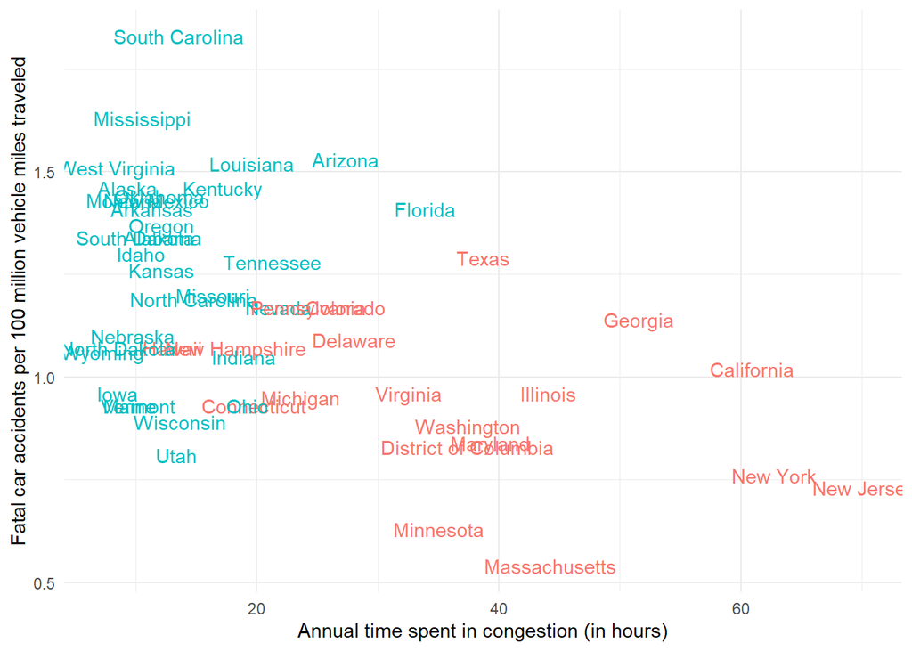

The results of dividing states into 3 groups using the k-means method are presented in the tables below and on the chart.

```
##
##  Descriptive statistics by group
## group: 1
##                                vars  n  mean   sd median trimmed  mad   min
## travel_time_to_work               1 23 24.82 1.74  24.60   24.86 1.78 21.70
## hours_in_congestion               2 23 19.23 8.02  18.93   18.52 8.21  8.40
## fatalities                        3 23  1.17 0.24   1.17    1.16 0.36  0.81
## roads_in_acceptable_conditions    4 23  0.77 0.07   0.78    0.78 0.07  0.57
## bridges_in_poor_conditions        5 23  0.06 0.04   0.04    0.05 0.05  0.01
##                                  max range  skew kurtosis   se
## travel_time_to_work            27.40  5.70 -0.16    -1.12 0.36
## hours_in_congestion            38.73 30.33  0.66    -0.38 1.67
## fatalities                      1.63  0.82  0.41    -1.14 0.05
## roads_in_acceptable_conditions  0.87  0.30 -0.89     0.54 0.01
## bridges_in_poor_conditions      0.14  0.13  0.46    -0.86 0.01
## ------------------------------------------------------------
## group: 2
##                                vars  n  mean    sd median trimmed   mad   min
## travel_time_to_work               1 11 29.46  2.72  29.30   29.70  1.48 23.50
## hours_in_congestion               2 11 46.86 12.68  44.11   45.87 11.03 32.56
## fatalities                        3 11  0.84  0.17   0.84    0.85  0.18  0.54
## roads_in_acceptable_conditions    4 11  0.77  0.12   0.75    0.78  0.13  0.53
## bridges_in_poor_conditions        5 11  0.06  0.03   0.07    0.06  0.05  0.02
##                                  max range  skew kurtosis   se
## travel_time_to_work            33.30  9.80 -0.51    -0.23 0.82
## hours_in_congestion            70.15 37.59  0.57    -1.32 3.82
## fatalities                      1.14  0.60 -0.10    -1.06 0.05
## roads_in_acceptable_conditions  0.93  0.40 -0.38    -0.77 0.04
## bridges_in_poor_conditions      0.12  0.09  0.32    -1.59 0.01
## ------------------------------------------------------------
## group: 3
##                                vars  n  mean   sd median trimmed  mad   min
## travel_time_to_work               1 16 20.69 2.86  20.00   20.65 3.11 17.00
## hours_in_congestion               2 16 11.55 3.53  10.93   11.16 2.16  7.25
## fatalities                        3 16  1.32 0.21   1.34    1.31 0.14  0.96
## roads_in_acceptable_conditions    4 16  0.90 0.04   0.90    0.90 0.05  0.82
## bridges_in_poor_conditions        5 16  0.06 0.02   0.05    0.06 0.02  0.03
##                                  max range  skew kurtosis   se
## travel_time_to_work            25.00  8.00  0.23    -1.61 0.71
## hours_in_congestion            21.29 14.04  1.34     1.27 0.88
## fatalities                      1.83  0.87  0.36     0.21 0.05
## roads_in_acceptable_conditions  0.96  0.14 -0.42    -0.93 0.01
## bridges_in_poor_conditions      0.10  0.08  0.32    -1.13 0.01
```

As a result of dividing objects into 3 clusters, a blue group emerged with a very short commute time, low congestion, a relatively high fatality rate, and good road conditions. The next group - red - is characterized by average values of all four variables. Residents of states classified into the green group spend the most time in traffic jams and commuting to work. At the same time, this group has the lowest average fatality rate in accidents.

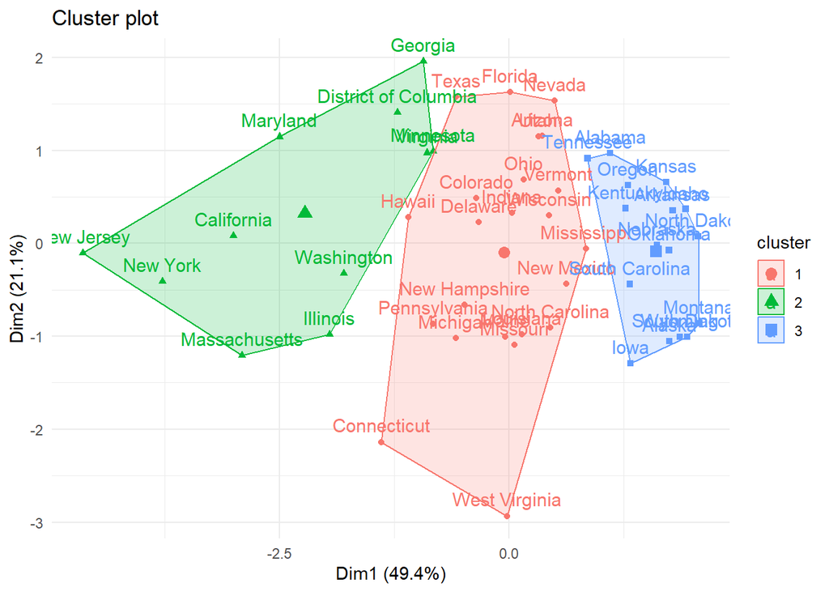

THe feature of divisive clustering methods is that the optimal number of clusters is not known in advance. As the value of k increases, the distances between objects within the same clusters practically keep decreasing because they are closer to a different centroid, even if the partition is clearly incorrect. So, how do we find the optimal value of k in the k-means method? One possible way is the elbow method, which involves selecting the number of clusters for which the Within-cluster Sum of Squares (WSS) shows the largest “jump.” WSS is the sum of distances between objects and the centroid within each cluster. You should choose a number of clusters such that adding another one does not significantly improve the overall WSS.

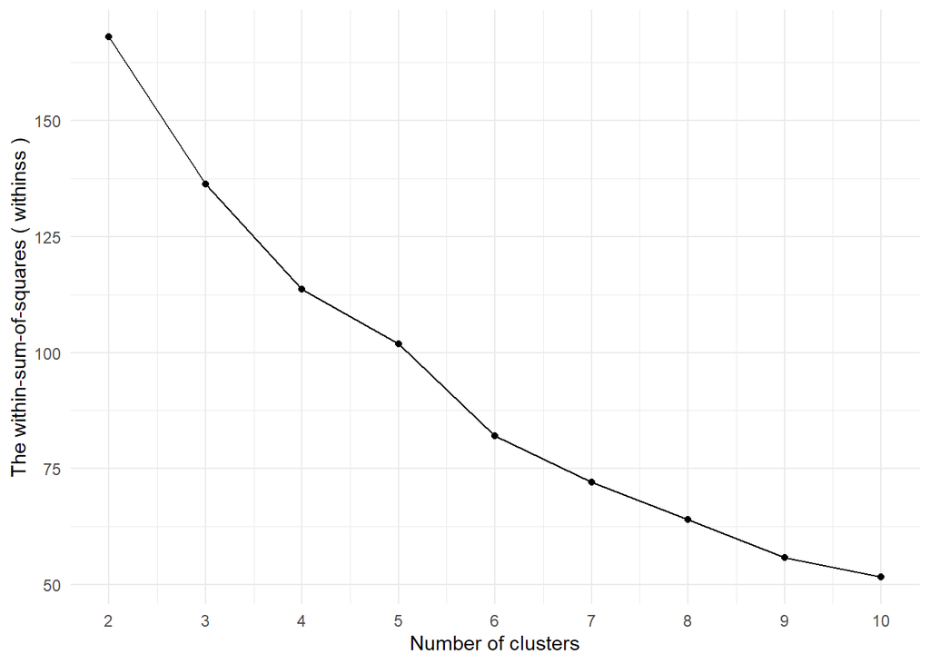

The division of states concerning transportation infrastructure into 4 groups is presented in the chart below. One of the groups, representing states such as Nebraska or Arkansas, is characterized by a short commute time to work and low congestion, with a high fatality rate in accidents. The second group includes states with higher values for the first two variables and a road condition rate of around 70%. The third group has slightly longer commute times and excellent road and bridge conditions. The fourth group consists of states with very long commute times and low fatality rates in accidents. Thus, with the division into 4 clusters, values of every variable have already been taken into account.

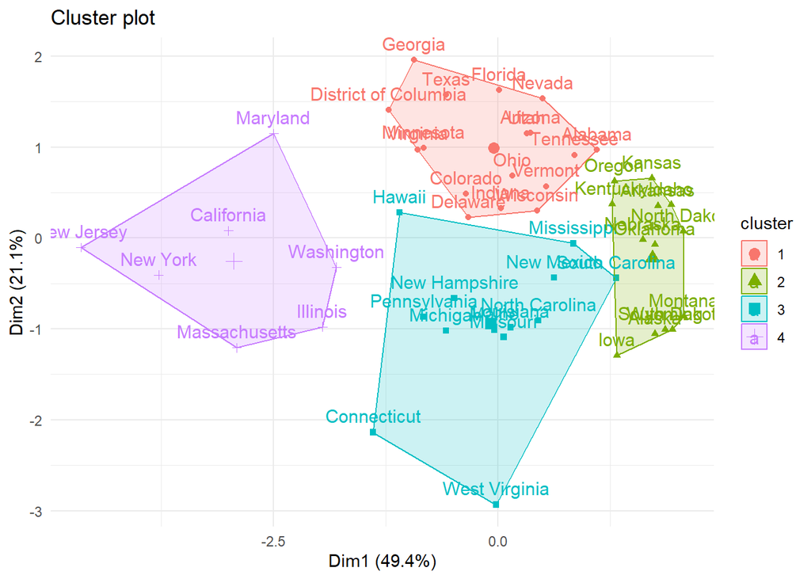

On the chart below, the differentiation of states into groups is presented once again, taking into account the average time residents of a given state spend annually in traffic jams and the fatality rate in road accidents. However, this time, the division is made with respect to 4 clusters. We can observe that considering only these two variables, the boundary between groups is not as distinct as it was for k=2. The influence of other features on classification has become more apparent.

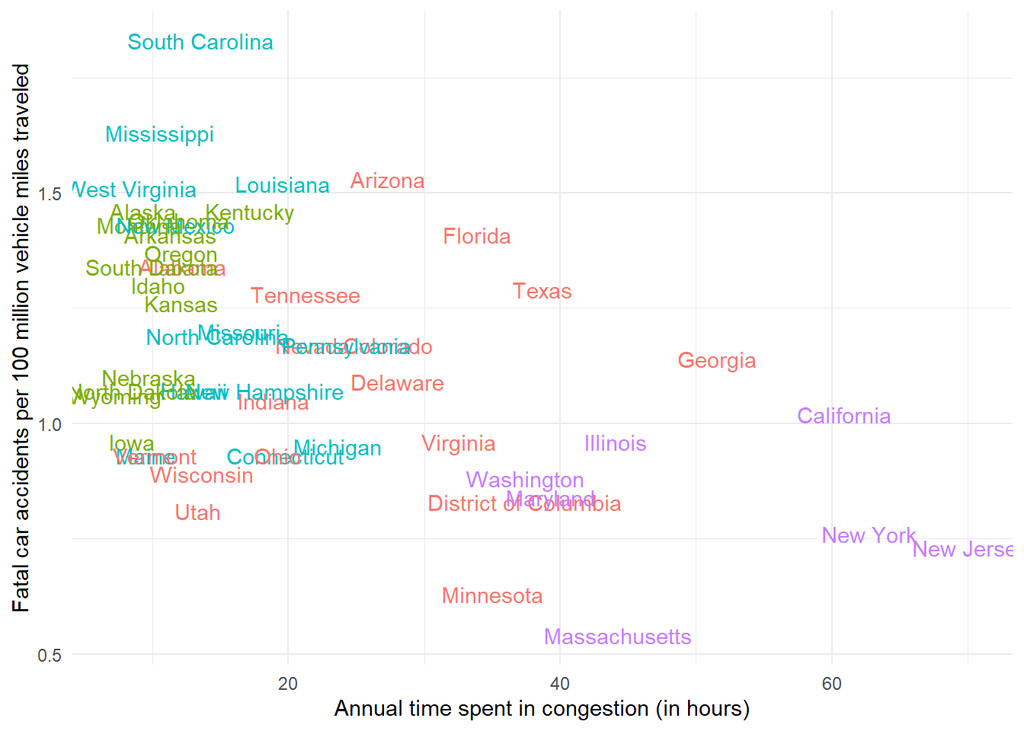

### Hierarchical clustering

In case of hierarchical clustering, individual objects are grouped together in such a way that they are divided by the smallest possible distances. These algorithms do not require the prior specification of the number of groups. The optimal number of groups can be determined later, for example, after analyzing the dendrogram.

Before applying the algorithm, it is necessary to normalize variables to ensure that distances between objects are not distorted if individual dimensions are expressed in different units.

#### Ward metohd

To begin with, we will perform object clustering using the Ward’s method. The chart below shows 4 dendrograms depending on the distance measure used. Ultimately, the Euclidean distance will be used for calculations, as it is the most commonly used distance in machine learning algorithms. In this study, once again, the decision was made not to include the state of Rhode Island.

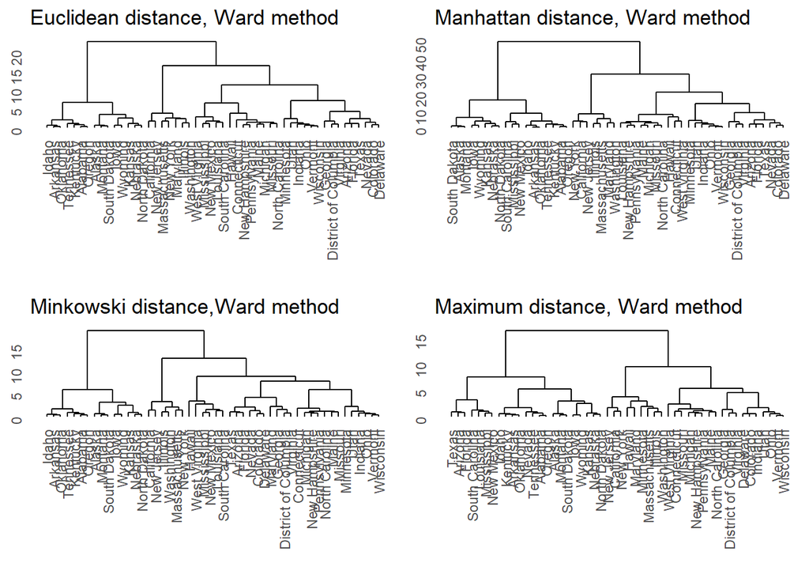

When using hierarchical clustering method, it is essential to identify the point at which further clustering should be stopped. It is advisable to choose the number of clusters for which the difference between this number and the next level on the dendrogram is sufficiently large. On the chart below, the dashed line intersects the dendrogram, classifying objects into 4 groups.

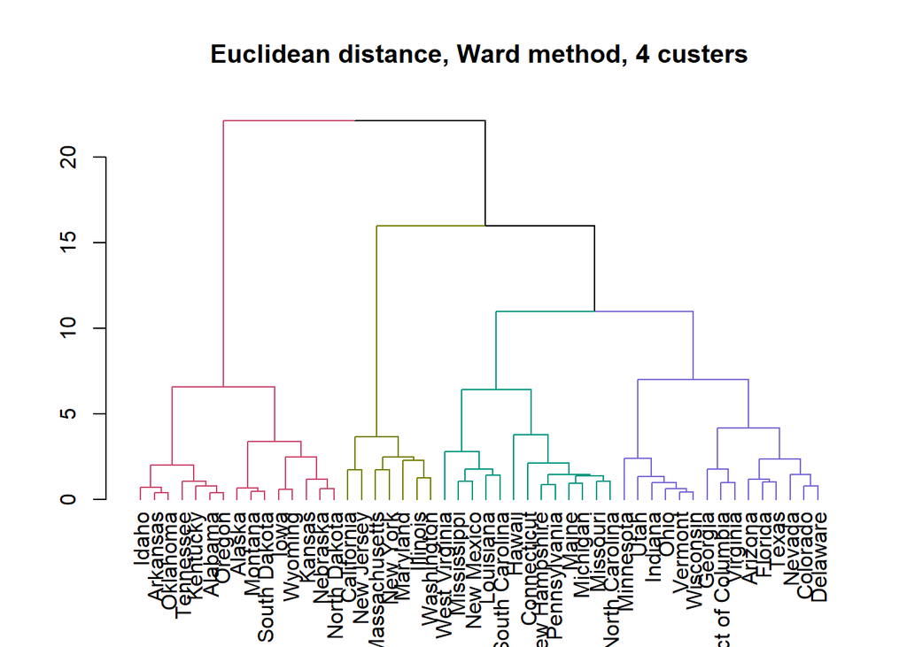

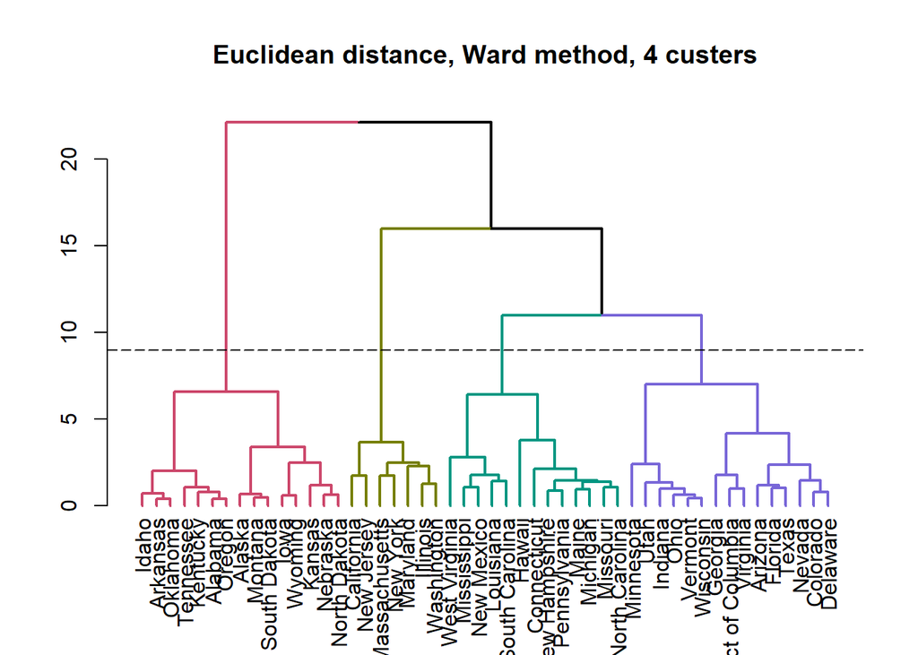

In the above dendrogram, it is evident that the clusters formed in the clustering process are clearly separated from each other. The branches of the resulting tree at the chosen intersection point lead to the formation of clusters with a meaningful selection of objects that share common characteristics. The discontinuity in the linkage distance chart below, concerning the stages of linkage, suggests that 4 clusters (but also 2 or 3) are the optimal numbers for our data.

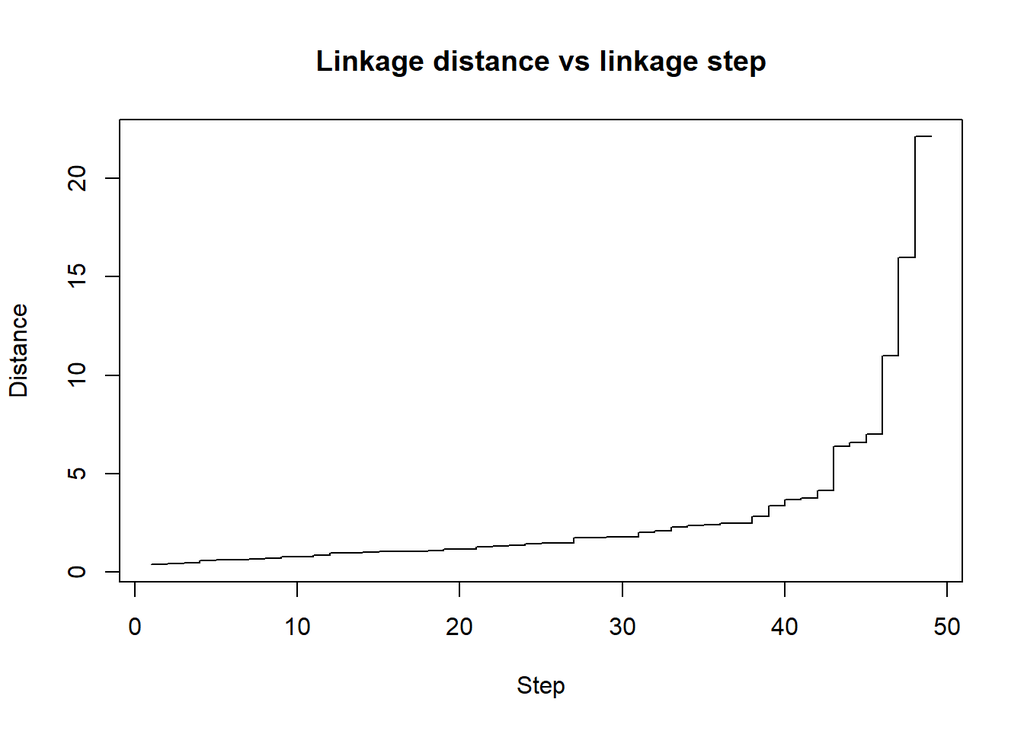

```
##           G1        G2        G3         S  k
## 2   1.763314 0.2674830 0.3609283 0.2069841  2
## 3  -2.641956 0.5312067 0.3967062 0.2223369  3
## 4  -3.488042 0.6627309 0.4192836 0.2576824  4
## 5  -2.594842 0.6869456 0.3959692 0.2471603  5
## 6  -2.022167 0.6546279 0.3885005 0.2385564  6
## 7  -1.756259 0.7562156 0.3885164 0.2681702  7
## 8  -1.394479 0.7831907 0.3662593 0.2683877  8
## 9  -1.292170 0.8233033 0.3446846 0.2755277  9
## 10 -1.202398 0.8732091 0.4394179 0.2725082 10
```

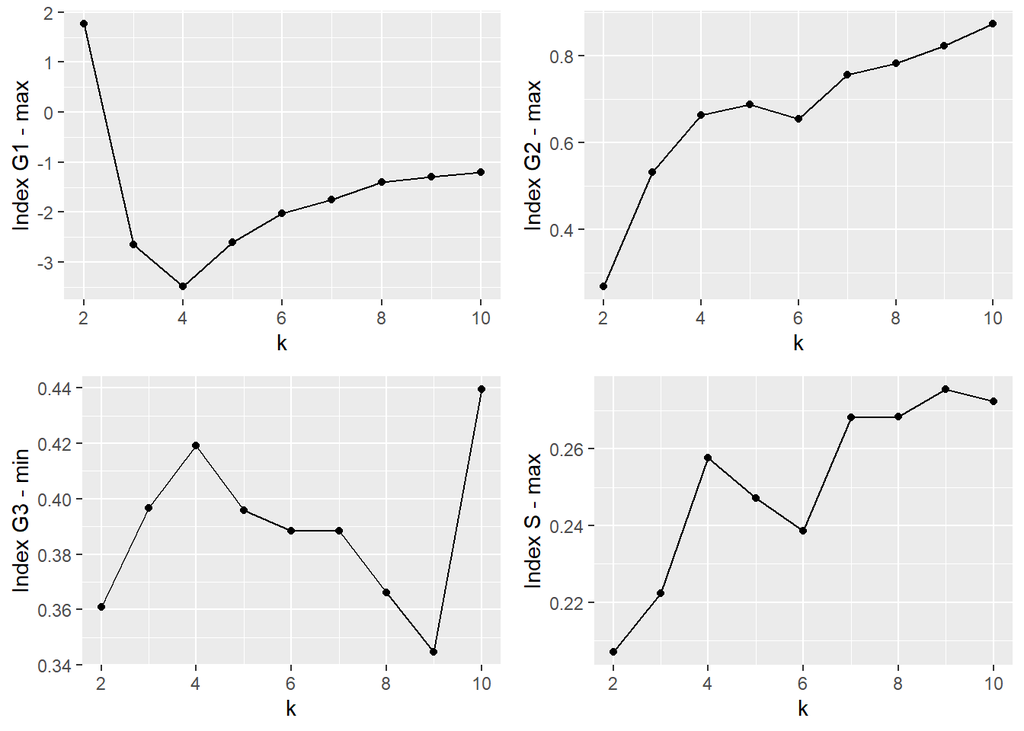

## Multidimensional scaling

The aim of multidimensional scaling is to represent objects expressed through n variables in an m-dimensional space, where m is smaller than n. Multidimensional scaling seeks to arrange objects in such a way that despite the reduction in dimensions, similar objects remain close to each other. If m is less than or equal to 3, the results of scaling can be represented on a graph.

### Classical multidimensional scaling

By applying the algorithm of classical multidimensional scaling, the goal is to reduce dimensions in a way that minimizes distortions in the true distances between objects. As a result of scaling our data into a two-dimensional space, the following outcome is obtained. The state of Rhode Island has not been included in the dataset.

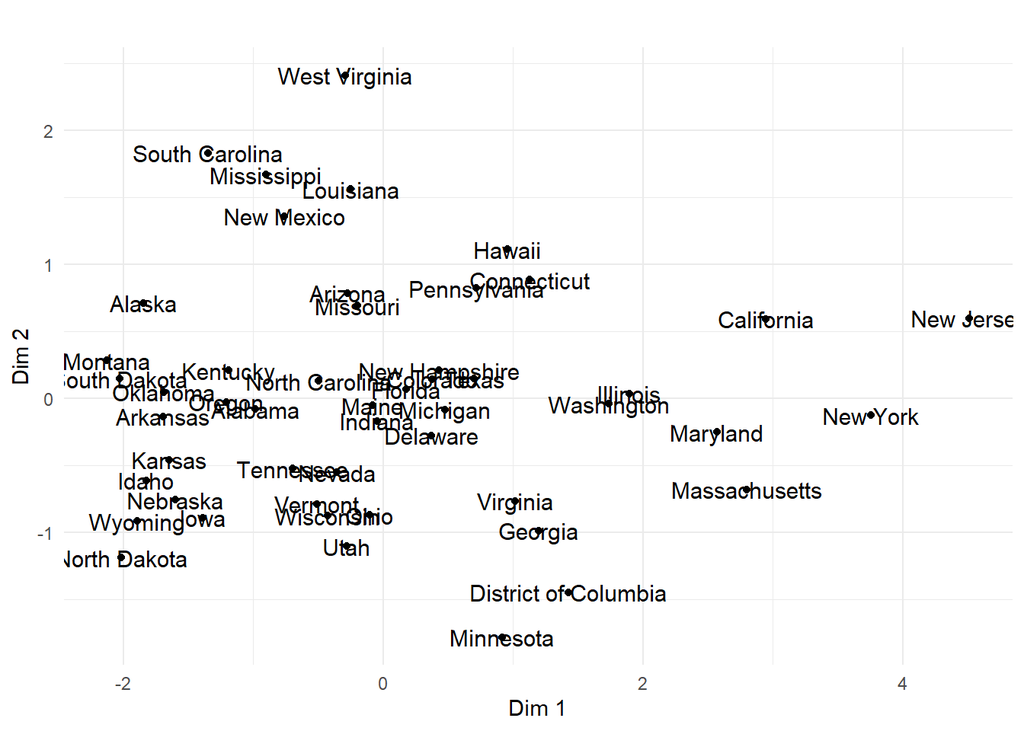

On the chart, we can also observe certain relationships. States with high values on the first dimension, including New York, New Jersey, and Maryland, are characterized by long average commute times to work and longer time spent in traffic jams. The higher on the chart, the higher the fatality rates in road accidents (e.g., West Virginia 1.51, South Carolina 1.83). In the upper right corner, there are states with poor road conditions (New Jersey, Hawaii, California), while in the lower left corner, there are states whose residents spend relatively less time in traffic jams and commuting to work (North Dakota, Wyoming).

Comparing the results of multidimensional scaling with cluster analysis, we can see that similar objects, which are close to each other after scaling into two dimensions, have also been classified into the same groups in the cluster analysis.

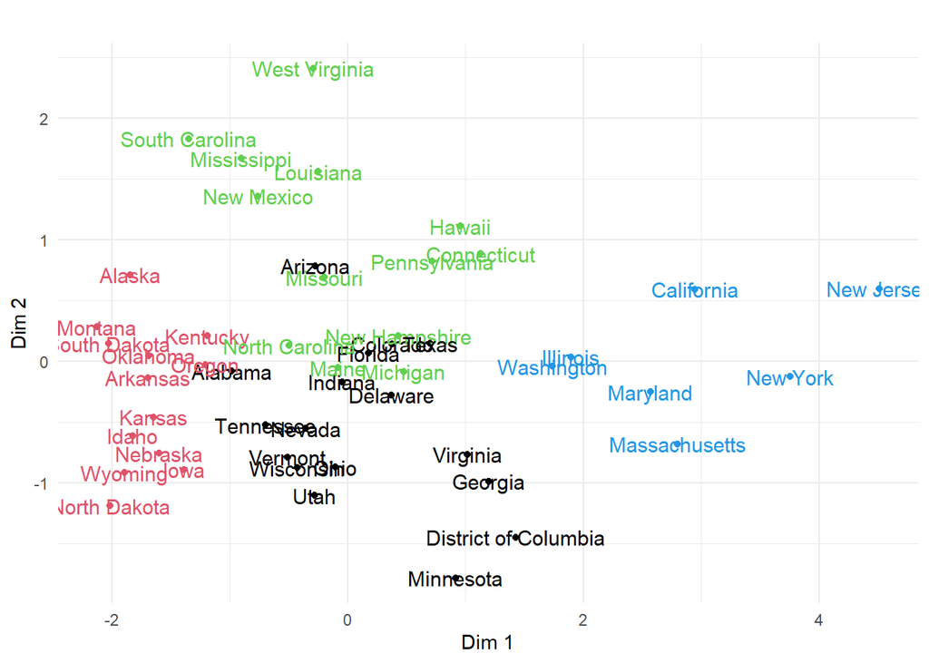

The quality of mapping real data onto a space with fewer dimensions is measured by the STRESS coefficient. The lower the STRESS value, the better the fit of the reconstructed distance matrix to the actual distance matrix. In our case, the very high STRESS coefficient of 6.82 indicates a very poor fit of the distance matrices. We can improve the quality of the fit by increasing the dimensionality of the space onto which we project our data.

```
## [1] 6.820003
```

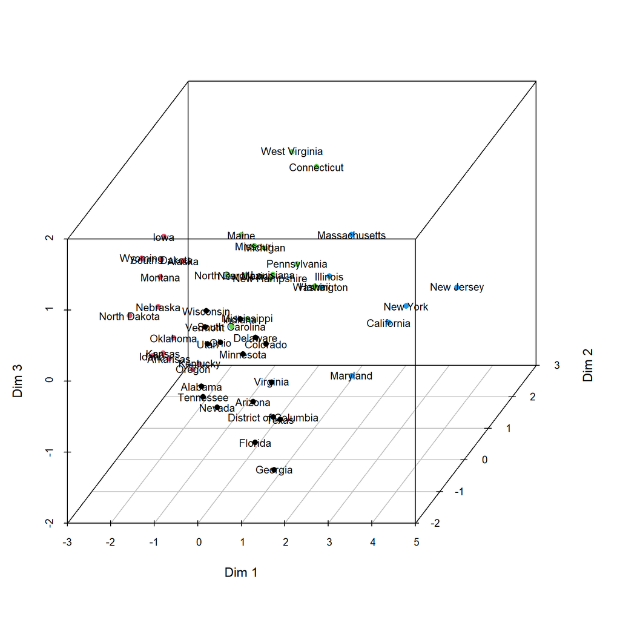

As a result of increasing the dimensionality of the projection space, the STRESS coefficient has decreased, but it still assumes a very high value, indicating a poor fit of the distance matrices.

```
## [1] 2.834104
```

### Sammon projection

The Sammon’s method, similarly to classical multidimensional scaling, reduces the number of dimensions in the data in such a way that the distances between objects in the new coordinate system are similar to the original distances between objects. However, its advantage over the classical method is that, thanks to a suitable choice of weights, it better represents small distances.

```
## Initial stress        : 0.08081
## stress after  10 iters: 0.04319, magic = 0.461
## stress after  20 iters: 0.04027, magic = 0.500
## stress after  30 iters: 0.03993, magic = 0.500
## stress after  40 iters: 0.03979, magic = 0.500
## stress after  50 iters: 0.03971, magic = 0.500
```

```
##                             [,1]        [,2]
## Alabama              -0.99125162  0.43382979
## Alaska               -2.30487115  0.71069738
## Arizona              -0.16894508  1.45033130
## Arkansas             -1.78034339  0.19653589
## California            3.24048704  0.80507296
## Colorado              0.30042460  0.18776122
## Connecticut           1.76883456  1.10930867
## Delaware              0.36862748 -0.28263867
## District of Columbia  1.69629019 -1.64163101
## Florida               0.41715391  1.19759400
## Georgia               1.41037810 -1.94166202
## Hawaii                1.42729688  2.18769068
## Idaho                -2.00933029 -0.24137976
## Illinois              2.33120414 -0.04291947
## Indiana              -0.10996811 -0.48444507
## Iowa                 -1.77406471 -1.73231077
## Kansas               -1.72195568 -0.52781816
## Kentucky             -1.35171669  0.67399386
## Louisiana            -0.29497180  1.70444518
## Maine                 0.20692070 -0.84277471
## Maryland              2.76537006 -0.62623896
## Massachusetts         3.09850926 -1.48334384
## Michigan              0.74928976 -0.39368851
## Minnesota             0.63611676 -2.15610011
## Mississippi          -1.01207694  1.99670347
## Missouri             -0.09591346  0.59826057
## Montana              -2.55859953  0.26199250
## Nebraska             -1.76088292 -0.97167594
## Nevada               -0.47740747 -0.35947584
## New Hampshire         0.68103661  0.10217677
## New Jersey            4.77240286  0.90012036
## New Mexico           -0.92907086  1.58765587
## New York              4.03201430 -0.57380011
## North Carolina       -0.46471283  0.19691315
## North Dakota         -2.36042806 -1.13354580
## Ohio                 -0.20591860 -1.05247404
## Oklahoma             -1.87142675  0.43624029
## Oregon               -1.26630549  0.32212532
## Pennsylvania          0.87952038  0.57934982
## South Carolina       -1.69560417  2.14087243
## South Dakota         -2.61419134 -0.09298648
## Tennessee            -0.93199605 -0.11868026
## Texas                 0.97078462  1.01250575
## Utah                 -0.42053433 -1.95889133
## Vermont              -0.63120873 -1.15620647
## Virginia              1.11016362 -0.89164862
## Washington            1.79910267 -0.23066687
## West Virginia        -0.04582468  2.91729362
## Wisconsin            -0.51392380 -1.30145063
## Wyoming              -2.29848397 -1.47101741
```

```
## Initial stress        : 0.08081
## stress after  10 iters: 0.04319, magic = 0.461
## stress after  20 iters: 0.04027, magic = 0.500
## stress after  30 iters: 0.03993, magic = 0.500
## stress after  40 iters: 0.03979, magic = 0.500
## stress after  50 iters: 0.03971, magic = 0.500
```

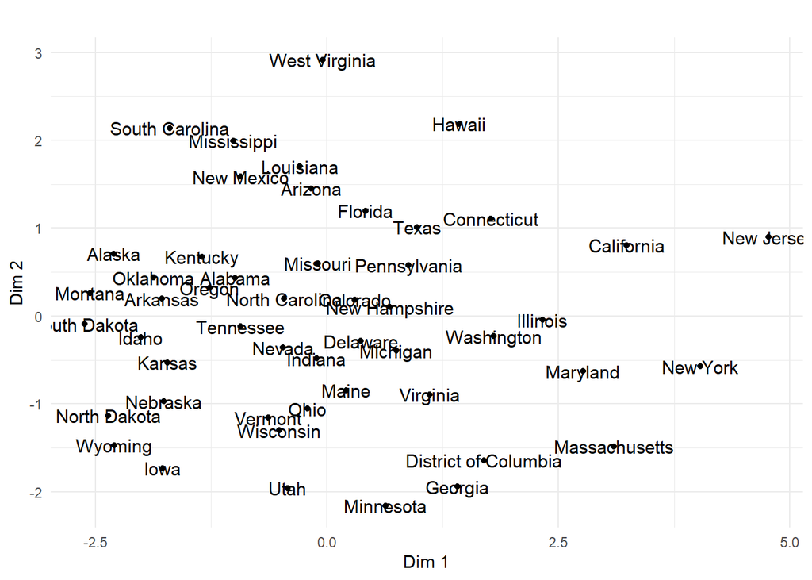

```
## [1] 0.03970953
```

We can see that as a result of scaling with the Sammon’s method, the objects are positioned in a two-dimensional space similarly to classical scaling. However, there are slight differences visible. Similar objects are still close to each other, confirming the comparison of scaling with the result of the earlier cluster analysis (chart below). However, the STRESS coefficient has significantly decreased, now standing at only 3.9%, indicating a very good fit between the distance matrices of the fitted and observed objects.

```
## Initial stress        : 0.08081
## stress after  10 iters: 0.04319, magic = 0.461
## stress after  20 iters: 0.04027, magic = 0.500
## stress after  30 iters: 0.03993, magic = 0.500
## stress after  40 iters: 0.03979, magic = 0.500
## stress after  50 iters: 0.03971, magic = 0.500
```

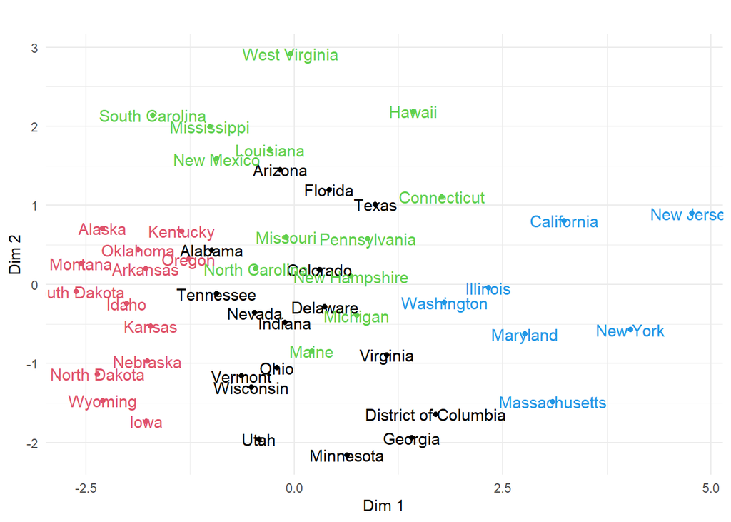

By increasing the number of projection dimensions by one, we obtain a STRESS coefficient of 0.7%, which indicates an exceptionally good fit between the reconstructed and observed distance matrices.

```
## Initial stress        : 0.01895
## stress after  10 iters: 0.00785, magic = 0.461
## stress after  20 iters: 0.00756, magic = 0.500
## stress after  30 iters: 0.00756, magic = 0.500
```

```
##                             [,1]         [,2]        [,3]
## Alabama              -0.93868140 -0.108439561 -1.04089657
## Alaska               -1.97236583  0.733855001  0.53311212
## Arizona              -0.26669116  0.781754758 -1.58597054
## Arkansas             -1.77001038 -0.102880737 -0.61004723
## California            3.10162014  0.864392639 -0.41780115
## Colorado              0.35210572  0.158796781 -0.48010226
## Connecticut           1.08391035  0.917124793  1.79490764
## Delaware              0.43389954 -0.224282965 -0.20176427
## District of Columbia  1.58227878 -1.587960549 -0.88521028
## Florida               0.11357345 -0.033115177 -1.87970146
## Georgia               1.24086336 -1.049160460 -2.01626036
## Hawaii                1.28221464  2.130784052 -0.40515898
## Idaho                -1.97698339 -0.501511862 -0.37421868
## Illinois              2.13329392 -0.008434612  0.91149456
## Indiana              -0.04528697 -0.378189041  0.11908386
## Iowa                 -1.49114006 -0.702624032  1.70411092
## Kansas               -1.64336719 -0.822533085 -0.19891483
## Kentucky             -1.29079715  0.295718948 -0.78115545
## Louisiana            -0.24524377  1.567333345 -0.11859738
## Maine                -0.05458631 -0.116843726  1.32621985
## Maryland              2.63568160 -0.373203246 -0.93420015
## Massachusetts         2.82954522 -0.706103285  1.62238036
## Michigan              0.51570383 -0.045959298  1.05108828
## Minnesota             0.97672471 -1.880995657  0.46858305
## Mississippi          -0.82607254  1.702657671 -0.86380302
## Missouri             -0.20152232  0.705454568  0.70017314
## Montana              -2.30038600  0.321528149  0.46141850
## Nebraska             -1.64344260 -0.829947017  0.54471932
## Nevada               -0.27023592 -0.744397463 -0.96881925
## New Hampshire         0.51508626  0.291833815  0.52909421
## New Jersey            4.63998379  1.121892186  0.05436551
## New Mexico           -0.85085794  1.592053646  0.10930043
## New York              3.90073754 -0.482503950  0.44603049
## North Carolina       -0.59538720  0.293610312  0.62691847
## North Dakota         -2.12258243 -1.207274292  0.61830927
## Ohio                 -0.06581407 -0.984699913  0.08798855
## Oklahoma             -1.84947101  0.166396023 -0.41575704
## Oregon               -1.19369405 -0.079897789 -0.77666760
## Pennsylvania          0.71213020  0.834059066  0.39554949
## South Carolina       -1.55902959  1.787000354 -1.09841428
## South Dakota         -2.21927372  0.201472099  0.85554649
## Tennessee            -0.81824718 -0.587706417 -1.10367905
## Texas                 0.74088629  0.266188008 -1.56444591
## Utah                 -0.24025749 -1.917179100  0.26733097
## Vermont              -0.44270232 -1.141465295  0.29957577
## Virginia              1.09725812 -0.762770412 -0.60508397
## Washington            1.74516741  0.005277637  0.34773664
## West Virginia        -0.35240977  2.452396346  1.43882247
## Wisconsin            -0.36297531 -1.053297932  0.61616444
## Wyoming              -2.02314978 -0.758203325  1.39664492
```

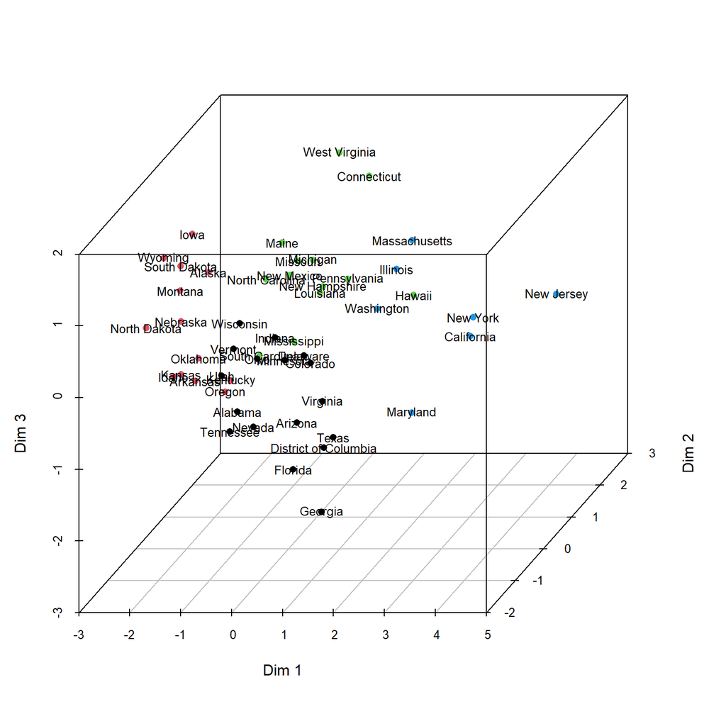

```
## [1] 0.007555449
```

## Summary

In this project, an attempt was made to build a ranking of U.S. states based on transportation infrastructure data, including road and bridge conditions, fatality rates in accidents, congestion levels, and average commuting time. After analyzing the results, it can be concluded that high-quality rankings were achieved. They sensibly reflect which states have better or worse transportation infrastructure compared to others. Despite some differences in the order depending on the linear ranking method used, we managed to identify which states boast the best transportation infrastructure and which ones should take appropriate steps to improve it. The validity of the ranking is confirmed by the fact that 6 out of the top 10 positions also appear in the Transportation Rankings published by U.S. News.

Cluster analysis also yielded good results. The classification successfully divided states into 4 groups that clearly differ in terms of the considered variables. At the same time, objects within each group are very similar. The division into 4 groups was considered optimal, guided by intuition, making it a subjective choice. Dividing states into 2 or 3 groups could also result in well-interpretable outcomes.

Multidimensional scaling successfully presented the data in two- and three-dimensional spaces. Particularly good representation was achieved using the Sammon’s method. By visualizing the data on a chart, we could better observe which states are similar to each other in terms of transportation infrastructure and which ones differ significantly.